# Дискретный Байесовский фильтр

```python
import book_format
book_format.set_style()
import warnings
warnings.filterwarnings("ignore")
```

Фильтр Калмана принадлежит к семейству фильтров, называемых Байесовскими фильтрами. В большинстве учебников по фильтру Калмана представлена Байесовская формула, возможно, показано, как она учитывается в уравнениях фильтра Калмана, но в основном обсуждение ведется на очень абстрактном уровне.

Такой подход требует довольно глубокого понимания нескольких областей математики, и он по-прежнему оставляет большую часть работы по пониманию и формированию интуитивного представления о ситуации на усмотрение читателя.

Давайте снова проведем простой мысленный эксперимент, подобный тому, который мы провели с фильтром g-h, порассуждаем об использовании вероятностей для фильтрации и отслеживания.

## Мысленный эксперимент

Давайте начнем с простой, но при этом футаристичной задачи. Мы работаем в большой корпорации, где разрешено иметь личный квадракоптер-доставщик, будем называть его Делив-01, практически у каждого на работе есть свой Делив. Иногда Деливы выходят из офисов и летят по коридорам доставляя информацию в соседние офисы. Мы хотим иметь возможность отслеживать их. Для этого в корридоре нашей корпорации установлены репиттеры для навигации внутри зданий, а наши Деливы оснащены ультрозвуковым эхолотом. Репиттер подает сигнал, прослушивает эхо, и по тому, как быстро возвращается эхо, можно определить, находится ли Делив перед открытой дверью или нет. Он также определяет, когда Делив летит, и сообщает, в каком направлении он двинулся. Репиттер подключается к сети через Wi-Fi и отправляет информацию раз в секунду.

Мы хотим отследить своего Делива-01, но для этого нам нужна программа для отслеживания его перемещения по зданию. На первый взгляд это может показаться невозможным. Но если мы начнем прислушиваться к датчику на борту Делива-01, то мы сможем распознать объекты типа: "дверь", "холл", "прихожая" и так далее. Как мы можем использовать эту информацию, чтобы определить, где находится Делив-01?

Чтобы задача была достаточно простой для моделирования, предположим, что в коридоре всего 10 позиций, которые мы пронумеруем от 0 до 9, где 1 находится справа от 0. По причинам, которые станут понятны позже, мы также предположим, что коридор круглый или прямоугольный. Если вы переместитесь вправо с позиции 9, то окажетесь на позиции 0.

Когда мы начинем записывать показания датчика, у нас не будет оснований полагать, что Делив-01 находится в каком-то определенном месте в коридоре. С нашей точки зрения, он с равной вероятностью может находиться в любом метсе. Существует 10 позиций, поэтому вероятность того, что он находится в любом заданном месте, равна 1/10.

Давайте релизуем наше представление о его позиции в виде массива NumPy.

```python
import numpy as np
belief = np.array([1/10]*10)
print(belief)
```

```
[0.1 0.1 0.1 0.1 0.1 0.1 0.1 0.1 0.1 0.1]
```

В [Байесовской статистике](https://en.wikipedia.org/wiki/Bayesian_probability) такую информацию называют [*a prior (априори - предварительно)*](https://en.wikipedia.org/wiki/Prior_probability). Это вероятность, предшествующая этапу получения измерений или любой другой информации. Более точно это называется *априорным (предварительным) распределением вероятности*. [*Распределение вероятностей*](https://en.wikipedia.org/wiki/Probability_distribution) - это совокупность всех возможных вероятностей для события. Сумма распределения вероятностей всегда равна 1, потому что что-то, точно, должно было произойти; в распределении перечислены все возможные события и вероятность каждого из них.

Я уверен, что вы уже использовали вероятности раньше - например, когда смотрели прогноз погоды "вероятность дождя сегодня составляет 30%". Последний абзац звучит примерно так же. Но Байесовская статистика произвела революцию в теории вероятностей, потому что она рассматривает вероятность как предположение об одном событии. Давайте рассмотрим пример. Я знаю, что если я буду подбрасывать монету неограниченное количество раз, то получу 50% орлов и 50% решек. Это называется [*частотная статистика*](https://en.wikipedia.org/wiki/Frequentist_inference). Вычисления основаны на частоте, с которой происходят события.

Я подбрасываю монету еще раз и позволяю ей упасть. Какой стороной, по моему мнению, она упала? Статистическая вероятность ничего не может сказать по этому поводу; она просто утверждает, что 50% подбрасываемых монет выпадают орлом. В некотором смысле бессмысленно определять вероятность текущего состояния монеты. Это либо орел, либо решка, мы просто не знаем, что именно. Байес рассматривает это как убеждение в отношении отдельного события - сила моего убеждения или знания о том, что этот конкретный бросок монеты выпадет орлом, составляет 50%.

Байесовская статистика учитывает прошлую информацию. Мы наблюдаем, что дождь идет 4 раза в 100 дней. Исходя из этого, я могу утверждать, что вероятность того, что завтра пойдет дождь, составляет 1/25. Прогноз погоды делается не так. Если я знаю, что сегодня идет дождь, а грозовой фронт остановился, то, скорее всего, завтра будет дождь. Прогноз погоды является Байесовским.

На практике статистики используют комбинацию частотных и Байесовских методов. Иногда найти априорные значения сложно или невозможно, и преобладают частотные методы. В нашем курсе мы сможем найти априорные значения. Когда я говорю о вероятности чего-либо, я имею в виду вероятность того, что какая-то конкретная вещь является правдой, учитывая прошлые события. При этом я использую Байесовский подход.

Теперь давайте создадим карту коридора. Мы разместим первые две двери вплотную друг к другу, а затем еще одну дверь подальше. Мы будем использовать 1 для дверей и 0 для стен:

```python
hallway = np.array([1, 1, 0, 0, 0, 0, 0, 0, 1, 0])
```

Я начинаю прослушивать передачи Делива-01 по сети, и первые данные, которые я получаю от датчика, - это **дверь**. На данный момент предположим, что датчик всегда выдает правильный ответ. Из этого я заключаю, что он находится перед дверью, но какой именно? У меня нет оснований полагать, что он находится перед первой, второй или третьей дверью. Что я могу сделать, так это присвоить каждой двери вероятность. Все двери одинаково вероятны, и их три, поэтому я присваиваю каждой двери вероятность 1/3.

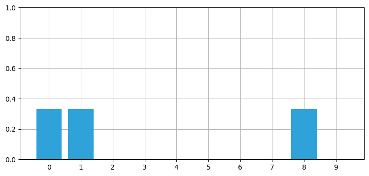

```python
import kf_book.book_plots as book_plots
import matplotlib.pyplot as plt

belief = np.array([1/3, 1/3, 0, 0, 0, 0, 0, 0, 1/3, 0])
book_plots.bar_plot(belief)
```

Это распределение называется [*категориальным распределением*](https://en.wikipedia.org/wiki/Categorical_distribution), которое представляет собой дискретное распределение, описывающее вероятность наблюдения n результатов. А также это [*мультимодальное распределение*](https://en.wikipedia.org/wiki/Multimodal_distribution), потому что у нас есть несколько представлений о положении нашего дрона. Конечно, мы не утверждаем, что, по нашему мнению, он находится одновременно в трех разных местах, просто мы сузили наши знания до одного из этих трех мест. По моему (Байесовскому) убеждению, вероятность оказаться у двери 0 составляет 33,3%, у двери 1 - 33,3%, а у двери 8 - 33,3%.

Мы отказались от ряда позиций в коридоре как от невозможных, и сила нашего убеждения об остальных позициях возросла с 10% до 33%. По мере того, как наше знание о том или ином процессе будут улучшаться, вероятность нашего прогноза будет стримиться к 100%.

Несколько слов о распределении [*мода*](https://en.wikipedia.org/wiki/Mode_%28statistics%29). Приведен список чисел, например {1, 2, 2, 2, 3, 3, 4}, *mode* - это число, которое встречается чаще всего. Для этого набора мода равна 2. Список {1, 2, 2, 2, 3, 3, 4, 4, 4} содержит моды 2 и 4, поскольку оба они встречаются трижды. Мы говорим, что первый список является [*унимодальным*](https://en.wikipedia.org/wiki/Unimodality), а второй - [*мультимодальным*](https://en.wikipedia.org/wiki/Multimodal_distribution).

Другим термином, используемым для обозначения этого распределения, является [*гистограмма*](https://en.wikipedia.org/wiki/Histogram). Гистограммы графически отображают распределение набора чисел. Столбчатая диаграмма выше является гистограммой.

В приведенном выше коде, мы вручную закодировали массив "убеждение". Давайте теперь поменяем подход.Обозначим двери как 1, а стены как 0, и умножим переменную hallway на процентное соотношение, вот так;

```python
belief = hallway * (1/3)
print(belief)
```

```
[0.333 0.333 0.    0.    0.    0.    0.    0.    0.333 0.   ]
```

## Извлечение информации из показаний датчиков

Отложим Python в сторону и немного поразмыслим над проблемой. Предположим, мы должны были прочитать следующее сообщение Делива-01:

- дверь
- переместиться вправо
- дверь

Можем ли мы определить местонахождение Делива-01? Конечно! Учитывая расположение коридоров, есть только одно место, откуда вы можете получить эту последовательность, и оно находится в левом конце. Таким образом, мы можем с уверенностью утверждать, что Делив-01 находится перед вторым дверным проемом. Если не совсем понятно, то рассмотрим другой пример. Предположим, что Делив-01 начал со второй или третьей двери. После перемещения вправо его датчик показал бы "стена". Это не соответствует показаниям датчика, поэтому мы знаем, что он начал не там. Мы можем продолжить в том же духе для всех остальных стартовых позиций. Единственный вариант остается на том, что он сейчас находится перед второй дверью. Наше убеждение заключается в том, что:

```python
belief = np.array([0., 1., 0., 0., 0., 0., 0., 0., 0., 0.])
```

Я замоделировал коридор и показания датчиков, чтобы быстро получить точный ответ. Реальные задачи не так очевидны. Но это должно подтолкнуть вашу интуицию - первые показания датчика дали нам лишь низкую вероятность (0,333) определения местоположения Делива-01, но после обновления местоположения и других показаний датчика мы знаем больше о том, где он находится. Вы можете справедливо предположить, что если бы у вас был очень длинный коридор с большим количеством дверей, то после нескольких показаний датчиков и обновления местоположения мы либо смогли бы узнать, где находится Делив-01, либо сузили бы круг возможных вариантов до небольшого числа. Это возможно, когда набор показаний датчиков совпадает только с одним из нескольких начальных местоположений.

Мы могли бы реализовать это решение уже сейчас, но вместо этого давайте рассмотрим реальное усложнение проблемы.

## Шумные датчики

Идеальные датчики встречаются редко. Возможно, датчик не обнаружил бы дверь, если бы Делив-01 завис перед ней, неправильно ее распознал, или если бы он не летел вдоль коридора. Таким образом, когда я нахожу **дверь**, я не могу использовать 1/3 в качестве вероятности. Я должен назначить менее 1/3 для каждой двери и назначить небольшую вероятность для каждого положения пустой стены. Что-то вроде

```
[.31, .31, .01, .01, .01, .01, .01, .01, .31, .01]
```

Если датчик работает с шумом, это ставит под сомнение все данные. Как мы можем заключить какой-либо вывод, если мы всегда не уверены?

Ответ, как и в случае с вышеприведенной проблемой, заключается в вероятностях. Мы уже привыкли к вероятностному предположению о местонахождении дрона; теперь нам нужно учесть дополнительную неопределенность, вызванную шумом датчика.

Допустим, мы получаем показания датчика **двери** и предполагаем, что тестирование показывает вероятность того, что датчик сработает правильно, в 3 раза выше, чем вероятность того, что он ошибется. Мы должны увеличить распределение вероятности на 3 там, где есть дверь. Если мы сделаем это, то результатом больше не будет распределение вероятностей, но мы скоро узнаем, как это исправить.

Давайте посмотрим на это в коде на Python. Здесь я использую переменную `z` для обозначения измерения. `z` или `y` - это обычные варианты в литературе для измерения.

```
belief: [0.3 0.3 0.1 0.1 0.1 0.1 0.1 0.1 0.3 0.1]
sum = 1.6000000000000003
```

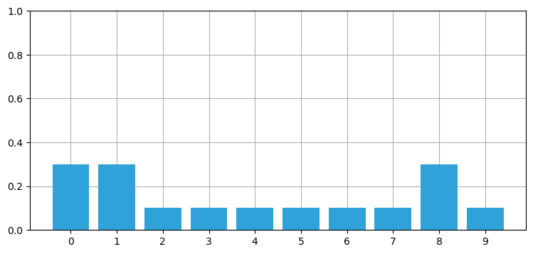

```python
def update_belief(hall, belief, z, correct_scale):
    for i, val in enumerate(hall):
        if val == z:
            belief[i] *= correct_scale

belief = np.array([0.1] * 10)
reading = 1 # 1 is 'door'
update_belief(hallway, belief, z=reading, correct_scale=3.)
print('belief:', belief)
print('sum =', sum(belief))
plt.figure()
book_plots.bar_plot(belief)
```

Это не распределение вероятностей, потому что в сумме оно не равно 1. Но код в целом работает правильно - дверям присваивается число (0,3), которое в 3 раза больше, чем у стен (0,1). Все что нам нужно сделать, это нормализовать результат, чтобы вероятности в сумме были равны 1. Нормализация выполняется путем деления каждого элемента на сумму всех элементов в списке. С NumPy это просто:

```python
belief / sum(belief)
```

```
array([0.188, 0.188, 0.062, 0.062, 0.062, 0.062, 0.062, 0.062, 0.188,
       0.062])
```

Немного странно говорить "вероятность того, что датчик окажется правым, в 3 раза выше, чем вероятность того, что он ошибается". Мы работаем с вероятностями, поэтому давайте определим вероятность того, что датчик окажется правым, и вычислим масштабный коэффициент, исходя из этого. Уравнение для этого выглядит следующим образом

$$scale = \frac{prob_{correct}}{prob_{incorrect}} = \frac{prob_{correct}} {1-prob_{correct}}$$

Кроме того, цикл `for` является громоздким. Как правило, вам следует избегать использования циклов `for` в коде NumPy. NumPy реализован на C и Fortran, поэтому, если вы нк используете цикл `for`, результат часто выполняется в 100 раз быстрее, чем аналогичный цикл.

Как нам избавиться от этого цикла `for`? NumPy позволяет индексировать массивы с помощью логических массивов. Вы создаете логический массив с помощью логических операторов. Мы можем найти все двери в коридоре с помощью:

```python
def normalize(pdf):
    pdf /= sum(np.asarray(pdf, dtype=float))
    return pdf
```

```python
hallway == 1
```

```
array([ True,  True, False, False, False, False, False, False,  True,
       False])
```

Когда вы используете логический массив в качестве индекса для другого массива, он возвращает только те элементы, индекс которых равен `True`. Таким образом, мы можем заменить цикл `for` на

```
belief[hall==z] *= scale
```

и только те элементы, которые равны `z`, будут умножены на `scale`.

Обучение NumPy выходит за рамки этого курса. Я буду использовать идиоматические конструкции NumPy и объясню их при первом представлении.

Вот наша улучшенная версия:

```
sum = 1.0
probability of door = 0.1875
probability of wall = 0.06249999999999999
```

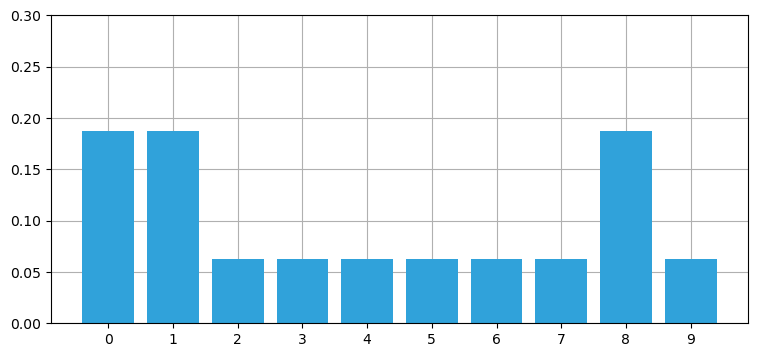

```python
def scaled_update(hall, belief, z, z_prob):
    scale = z_prob / (1. - z_prob)
    belief[hall==z] *= scale
    normalize(belief)

belief = np.array([0.1] * 10)
scaled_update(hallway, belief, z=1, z_prob=.75)

print('sum =', sum(belief))
print('probability of door =', belief[0])
print('probability of wall =', belief[2])
book_plots.bar_plot(belief, ylim=(0, .3))
```

Из выходных данных мы можем видеть, что сумма теперь равна 1 и что вероятность для двери по-прежнему в три раза больше. Результат также соответствует нашей интуиции которая говорит нам, что вероятность появления двери должна быть меньше 0,333, а вероятность появления стены - больше 0. Наконец, наша интуиция должна соответствовать тому, что нам еще не предоставили никакой информации, которая позволила бы нам различать любое заданное положение двери или стены, поэтому все положения дверей должны иметь одинаковое значение, и то же самое должно быть верно для положений стен.

Такой результат называют [*апостериори - posterior*](https://en.wikipedia.org/wiki/Posterior_probability), что является сокращением от *апостериорного распределения вероятности*. Все это означает распределение вероятности после включения информации об измерениях. Для сравнения, *prior* - это распределение вероятности до включения информации об измерениях.

Другой термин - это [*правдоподобие - likelihood*](https://en.wikipedia.org/wiki/Likelihood_function). Когда мы вычисляли `belief[hall==z] *= scale`, мы вычисляли, насколько *правдоподобно*, что каждая позиция была измерена. Правдоподобие не является распределением вероятностей, потому что в сумме она не равна единице.

Комбинация этих параметров дает уравнение

$$\mathtt{posterior} = \frac{\mathtt{likelihood} \times \mathtt{prior}}{\mathtt{normalization}}$$

Когда мы говорим о выходных данных фильтра, мы обычно называем состояние после выполнения прогнозирования *prior* или *прогнозом*, а состояние после обновления мы называем либо *posterior*, либо *оценкой состоя (системы)*.

Очень важно выучить и усвоить эти термины, поскольку они широко используются в большинстве публикаций.

Выполняет ли `scaled_update()` это вычисление? Да.

```python
def scaled_update(hall, belief, z, z_prob):
    scale = z_prob / (1. - z_prob)
    likelihood = np.ones(len(hall))
    likelihood[hall==z] *= scale
    return normalize(likelihood * belief)
```

Эта функция не является полностью общей. Она содержит сведения о коридоре и о том, как мы сопоставляем с ним измерения. Мы всегда стремимся писать общие функции. Здесь мы удалим вычисление вероятности из функции и потребуем, чтобы вызывающий объект сам вычислял вероятность.

Вот полная реализация алгоритма:

```
def update(likelihood, prior):
    return normalize(likelihood * prior)
```

Расчет вероятности зависит от конкретной задачи. Например, датчик может выдать не просто значение 1 или 0, а *плавающее значение* `float` между 0 и 1, указывающее на вероятность того, что вы находитесь перед дверью.

```python
def update(likelihood, prior):
    return normalize(likelihood * prior)
```

```python
def lh_hallway(hall, z, z_prob):
    """ compute likelihood that a measurement matches
    positions in the hallway."""

    try:
        scale = z_prob / (1. - z_prob)
    except ZeroDivisionError:
        scale = 1e8

    likelihood = np.ones(len(hall))
    likelihood[hall==z] *= scale
    return likelihood

belief = np.array([0.1] * 10)
likelihood = lh_hallway(hallway, z=1, z_prob=.75)
update(likelihood, belief)
```

```
array([0.188, 0.188, 0.062, 0.062, 0.062, 0.062, 0.062, 0.062, 0.188,
       0.062])
```

## Включающее движение

Вспомните, как быстро мы смогли найти точное решение, когда включили серию измерений и обновлений данных о перемещениях. Однако это происходило в вымышленном мире совершенных датчиков. Сможем ли мы найти точное решение с помощью шумных датчиков?

К сожалению, ответ отрицательный. Даже если показания датчиков идеально соответствуют чрезвычайно сложной карте коридора, мы не можем быть на 100% уверены, что дрон находится в определенном месте - в конце концов, существует крошечная вероятность того, что все показания датчиков были неверными! Естественно, в более типичной ситуации большинство показаний датчиков будут правильными, и мы можем быть уверены в своем ответе почти на 100%, но никогда - абсолютно. Это может показаться сложным, но давайте продолжим и запрограммируем математику.

Сначала давайте разберемся с простым случаем - предположим, что датчик движения исправен, и он сообщает, что дрон переместилась на одну позицию вправо. Как бы мы изменили наш массив `убеждений`?

Я надеюсь, что после недолгих размышлений станет ясно, что мы должны сдвинуть все значения на один пробел вправо. Если раньше мы считали, что вероятность того, что Делив-01 окажется на позиции 3, составляет 50%, то после того, как он переместился на одну позицию вправо, мы должны полагать, что вероятность того, что он окажется на позиции 4, составляет 50%. Коридор имеет круглую форму, поэтому для выполнения перемещения мы будем использовать арифметику по модулю.

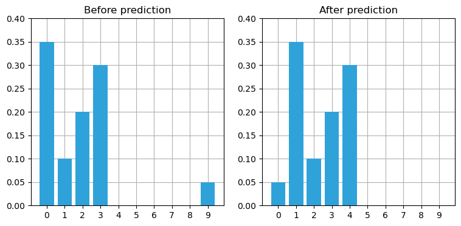

```python
def perfect_predict(belief, move):
    """ move the position by `move` spaces, where positive is
    to the right, and negative is to the left
    """
    n = len(belief)
    result = np.zeros(n)
    for i in range(n):
        result[i] = belief[(i-move) % n]
    return result

belief = np.array([.35, .1, .2, .3, 0, 0, 0, 0, 0, .05])
plt.subplot(121)
book_plots.bar_plot(belief, title='Before prediction', ylim=(0, .4))

belief = perfect_predict(belief, 1)
plt.subplot(122)
book_plots.bar_plot(belief, title='After prediction', ylim=(0, .4))
```

Мы видим, что мы правильно сдвинули все значения на одну позицию вправо, переместив их из конца массива обратно в начало.

## Терминология

Давайте остановимся на минутку, чтобы ознакомиться с терминологией. Мы столкнулись с этой терминологией в предыдущей главе, но давайте остановимся на секунду, чтобы закрепить знания.

Система - это то, что мы пытаемся смоделировать или отфильтровать. В данном случае система - это наш дрон. *Состояние* - это его текущая конфигурация или значение. В этой главе под состоянием понимается положение нашего дрона. Мы редко знаем фактическое состояние, поэтому говорим, что наши фильтры выдают *приблизительное состояние* системы. На практике это часто называют состоянием, поэтому будьте внимательны к пониманию контекста.

Один цикл прогнозирования и обновления с измерением называется состоянием или эволюцией системы, что сокращенно от [*эволюции во времени - Time Evolution*](https://en.wikipedia.org/wiki/Time_evolution). Другой термин - *распространение системы*. Он относится к тому, как состояние системы меняется с течением времени. Для фильтров время обычно представляет собой дискретный шаг, например, 1 секунду. Для нашего устройства отслеживания дрона, состояние системы - это положение дрона, а изменение состояния - это его положение по прошествии определенного периода времени.

Мы моделируем поведение системы с помощью *модели процесса*. В данном случае наша модель процесса заключается в том, что дрон перемещается на одну или несколько позиций на каждом временном шаге. Это не особенно точная модель поведения. Ошибка в модели называется *системной ошибкой* или *технологической ошибкой*.

Прогноз является нашим новым *prior*. Время ушло вперед, и мы сделали прогноз, не зная результатов измерений.

Давайте рассмотрим пример. Текущее положение дрона - 17 м. Наша эпоха длится 2 секунды, и дрон движется со скоростью 15 м/с. Где, по нашим прогнозам, он будет через две секунды?

Очевидно,

$$ \begin{aligned} \bar x &= 17 + (15*2) \\ &= 47 \end{aligned}$$

Я использую черточки над переменными, чтобы указать, что они являются предварительными (прогнозируемыми). Мы можем записать уравнение для модели процесса следующим образом:

$$ \bar x_{k+1} = f_x(\bullet) + x_k$$

$x_k$ это текущее положение или состояние. Если дрон находится на расстоянии 17 м, то $x_k = 17$.

$f_x(\bullet)$ является функцией распространения состояния для x. Она описывает, насколько сильно $x_k$ изменяется за один временной шаг. В нашем примере это $15 \cdot 2$ поэтому, мы бы определили это как

$f_x(v_x, t) = v_k t$.

## Добавление неопределенности к прогнозу

В функции `perfect_predict()` предполагается, что измерения выполнены идеально, но все датчики имеют помехи. Что, если датчик сообщил, что наш дрон переместился на одну позицию, но на самом деле он переместилась на две позиции или остался на месте? Это может показаться сложной задачей, но давайте попробуем смоделировать её.

Предположим, что измерение перемещения датчика с вероятностью 80% будет правильным, с вероятностью 10% - смещенно на одно положение вправо и 10% - влево. То есть, если показатель перемещения равен 4 (имеется в виду 4 шага вправо), то с вероятностью 80% Делив-01 переместился на 4 шага вправо, с вероятностью 10% - на 3 шага и с вероятностью 10% - на 5 шагов.

Теперь каждый результат в массиве должен включать вероятности для 3 различных ситуаций. Например, рассмотрим сообщение о перемещении 2. Если мы на 100% уверены, что дрон стартовал с позиции 3, то с вероятностью 80% он находится на позиции 5, а с вероятностью 10% - на позиции 4 или 6. Давайте попробуем это закодировать:

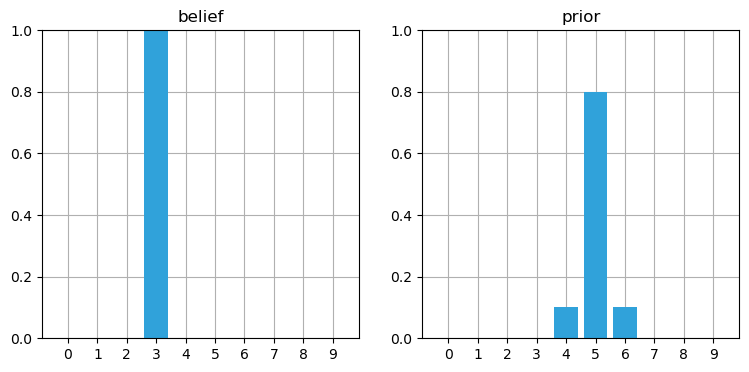

```python
def predict_move(belief, move, p_under, p_correct, p_over):
    n = len(belief)
    prior = np.zeros(n)
    for i in range(n):
        prior[i] = (
            belief[(i-move) % n]   * p_correct +
            belief[(i-move-1) % n] * p_over +
            belief[(i-move+1) % n] * p_under)
    return prior

belief = [0., 0., 0., 1., 0., 0., 0., 0., 0., 0.]
prior = predict_move(belief, 2, .1, .8, .1)
book_plots.plot_belief_vs_prior(belief, prior)
```

Похоже, что код работает верно. Что же происходит, когда наше убеждение равно не 100%?

```
array([0.  , 0.  , 0.  , 0.04, 0.38, 0.52, 0.06, 0.  , 0.  , 0.  ])
```

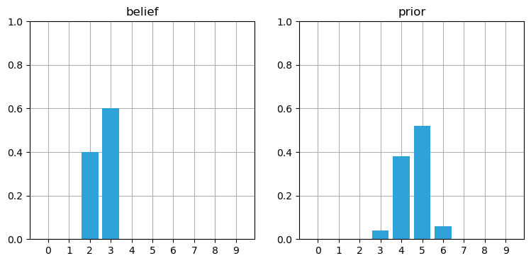

```python
belief = [0, 0, .4, .6, 0, 0, 0, 0, 0, 0]
prior = predict_move(belief, 2, .1, .8, .1)
book_plots.plot_belief_vs_prior(belief, prior)
prior
```

Здесь результаты более сложные, но вы все равно должны быть в состоянии просчитать их в уме. Значение 0,04 связано с возможностью того, что значение 0,4 меньше значения 1. Значение 0,38 обусловлено следующим: 80%-ной вероятностью того, что мы переместились на 2 позиции (0.4 $\times$ 0.8), и 10%-ной вероятностью того, что мы промахнулись (0.6 $\times$ 0.1). **Я настоятельно рекомендую проработать несколько примеров, пока все эти манипуляции не станут для вас предельно ясными, поскольку многое из того, что будет далее, зависит от понимания этого шага.**

Если вы посмотрите на вероятности после выполнения обновления, вы можете прийти в ужас. В приведенном выше примере мы начали с вероятностей 0.4 и 0.6 в двух позициях; после выполнения обновления вероятности не только уменьшились, но и распределились по всей карте.

Это не совпадение и не результат тщательно подобранного примера - все так как и должно быть с прогнозом. Если датчик имеет шум, мы теряем некоторую информацию о каждом прогнозе. Предположим, что мы должны были бы выполнять прогнозирование бесконечное число раз - каков был бы результат? Если мы будем терять информацию на каждом шаге, то в конечном итоге у нас не останется никакой информации вообще, и наши вероятности будут равномерно распределены по массиву `убеждение - belief`.

[figure not shown]

После 100 итераций мы потеряем почти всю информацию, хотя были на 100% уверены, что начали с позиции 0. Не стесняйтесь экспериментировать с цифрами, чтобы увидеть эффект от разного количества обновлений. Например, после 100 обновлений остается небольшое количество информации, после 50 - много, но к 200 итерациям практически вся информация теряется.

## (Генерализация) Обобщение с помощью свертки

Сохранить полезную информацию после перемещени можно с помощью [*свертки - convolution*](https://en.wikipedia.org/wiki/Convolution). Свертка изменяет одну функцию с помощью другой функции. В нашем случае мы изменяем распределение вероятностей с помощью функции ошибки датчика. Функция `predict_move()` - это свертка, хотя мы ее так не называли. Формально свертка определяется как

$$ (f \ast g) (t) = \int_0^t \!f(\tau) \, g(t-\tau) \, \mathrm{d}\tau$$

где $f\ast g$ это обозначение для преобразования f в g. Это не умножение.

Интегралы предназначены для непрерывных функций, но мы используем дискретные функции. Заменим интеграл суммированием, а круглые скобки - квадратными.

$$ (f \ast g) [t] = \sum\limits_{\tau=0}^t \!f[\tau] \, g[t-\tau]$$

[Introduction to the Convolution](https://www.khanacademy.org/math/differential-equations/laplace-transform/convolution-integral/v/introduction-to-the-convolution) содержит хорошее введение в свертку, а в Википедии есть несколько отличных [анимаций сверток](http://en.wikipedia.org/wiki/Convolution). Но общая идея уже ясна. Вы перемещаете массив, называемый *ядром - kernel*, по другому массиву, умножая значения соседей текущей ячейки на значения второго массива. В нашем примере, приведенном выше, мы использовали значение 0.8 для вероятности перемещения в правильное местоположение, 0.1 для вероятности недостаточного перемещения и 0.1 для вероятности превышения. Теперь мы будем использовать эти значения в виде массива `[0.1, 0.8, 0.1]`. Все, что нам нужно сделать, это написать цикл, который будет проходить по каждому элементу нашего массива, умножать на ядро и суммировать результаты. Чтобы подчеркнуть, что убждение - это распределение вероятностей, я назвал его `pdf`.

```python
def predict_move_convolution(pdf, offset, kernel):
    N = len(pdf)
    kN = len(kernel)
    width = int((kN - 1) / 2)

    prior = np.zeros(N)
    for i in range(N):
        for k in range (kN):
            print("Шаг по коридору", (i + (width-k) - offset) % N)
            index = (i + (width-k) - offset) % N
            print("Свертка {:.4f}".format(pdf[index] * kernel[k]))
            prior[i] += pdf[index] * kernel[k]
    return prior
```

Эта функция иллюстрирует алгоритм свертки. SciPy предоставляет свою функцию `convolve()` в модуле `ndimage.filters`. Перед сверткой нам необходимо сдвинуть pdf на некоторое значение `offset`; это делает `np.roll()`. Алгоритм перемещения и прогнозирования может быть реализован с помощью одной строки:

```
convolve(np.roll(pdf, offset), kernel, mode='wrap')
```

```python
from scipy.ndimage.filters import convolve
from scipy.ndimage import shift
def predict(pdf, offset, kernel, mode='wrap', cval=0.):
    if mode == 'wrap':
        return convolve(np.roll(pdf, offset), kernel, mode='wrap')

    return convolve(shift(pdf, offset, cval=cval), kernel,
                    cval=cval, mode='constant')
```

```
Шаг по коридору 0
Свертка 0.0050
Шаг по коридору 9
Свертка 0.0400
Шаг по коридору 8
Свертка 0.0050
Шаг по коридору 1
Свертка 0.0050
Шаг по коридору 0
Свертка 0.0400
Шаг по коридору 9
Свертка 0.0050
Шаг по коридору 2
Свертка 0.0050
Шаг по коридору 1
Свертка 0.0400
Шаг по коридору 0
Свертка 0.0050
Шаг по коридору 3
Свертка 0.0050
Шаг по коридору 2
Свертка 0.0400
Шаг по коридору 1
Свертка 0.0050
Шаг по коридору 4
Свертка 0.0550
Шаг по коридору 3
Свертка 0.0400
Шаг по коридору 2
Свертка 0.0050
Шаг по коридору 5
Свертка 0.0050
Шаг по коридору 4
Свертка 0.4400
Шаг по коридору 3
Свертка 0.0050
Шаг по коридору 6
Свертка 0.0050
Шаг по коридору 5
Свертка 0.0400
Шаг по коридору 4
Свертка 0.0550
Шаг по коридору 7
Свертка 0.0050
Шаг по коридору 6
Свертка 0.0400
Шаг по коридору 5
Свертка 0.0050
Шаг по коридору 8
Свертка 0.0050
Шаг по коридору 7
Свертка 0.0400
Шаг по коридору 6
Свертка 0.0050
Шаг по коридору 9
Свертка 0.0050
Шаг по коридору 8
Свертка 0.0400
Шаг по коридору 7
Свертка 0.0050
```

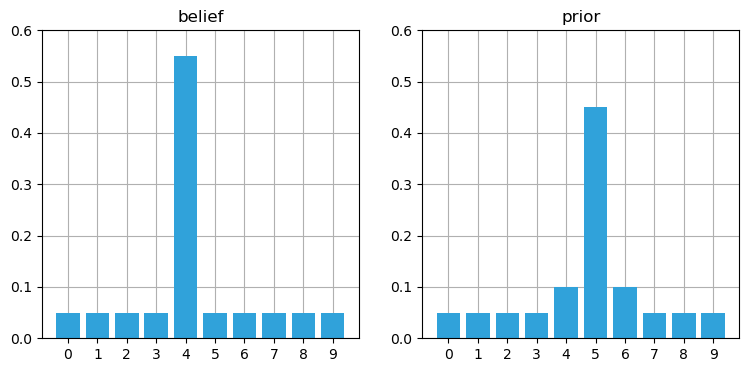

```python
belief = [.05, .05, .05, .05, .55, .05, .05, .05, .05, .05]
prior = predict_move_convolution(belief, offset=1, kernel=[.1, .8, .1])
predict(belief, offset=1, kernel=[.1, .8, .1])
book_plots.plot_belief_vs_prior(belief, prior, ylim=(0,0.6))
```

Все элементы остаются неизменными, за исключением значений посередине. Значения в позициях 4 и 6 должны быть $$(0.1 \times 0.05)+ (0.8 \times 0.05) + (0.1 \times 0.55) = 0.1$$

А позиция 5, следовательно $$(0.1 \times 0.05) + (0.8 \times 0.55)+ (0.1 \times 0.05) = 0.45$$

Давайте убедимся, что алгоритм правильно смещает позиции для перемещений, превышающих единицу, и для асимметричных ядер.

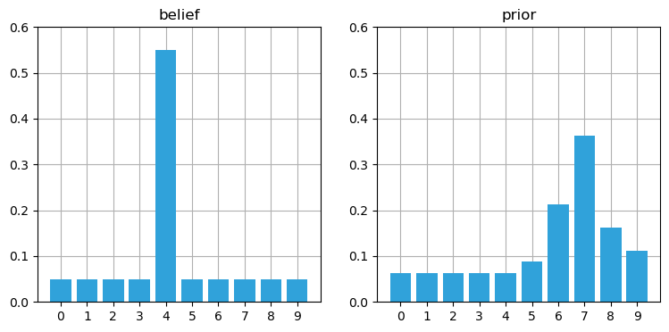

```python
prior = predict(belief, offset=3, kernel=[.05, .3, .6, .2, .1])
book_plots.plot_belief_vs_prior(belief, prior, ylim=(0,0.6))
```

Позиция была корректно сдвинута на 3 шага, и мы придаем большее значение вероятности шума датчика.

Убедитесь, что вы понимаете, что мы делаем. Мы прогнозируем, куда движется дрон, и вычисляем вероятности, чтобы получить априорную оценку положения.

Если бы мы не использовали вероятности, мы бы использовали это уравнение, которое я приводил ранее:

$$ \bar x_{k+1} = x_k + f_{\mathbf x}(\bullet)$$

Наш априорный прогноз о том, где будет находиться дрон, - это количество шагов, которое дрон пролетел, плюс его текущее положение. Но мы используем вероятности для моделирования процесса, поэтому наше уравнение выглядит следующим образом:

$$ \bar{ \mathbf x}_{k+1} = \mathbf x_k \ast f_{\mathbf x}(\bullet)$$

Мы *сверяем* текущую вероятностную оценку положения с вероятностной оценкой того, насколько, по нашему мнению, переместился дрон. Это та же концепция, но математика немного отличается. $\mathbf x$ выделен жирным шрифтом, чтобы обозначить, что это вектор.

## Интеграция измерений и обновлений данных о перемещениях

Из-за проблемы потери информации во время прогнозирования может показаться, что наша система быстро перестанет обладать полезными знаниями. Однако за каждым прогнозом следует обновление, в ходе которого мы включаем результаты измерений в наш прогноз. Это обновление улучшает наше представление о ситуации. Результаты этапа обновления передаются в следующий прогноз. Прогноз снижает нашу оценку. И его мы тоже передаем в другой этап обновления, где достоверность снова повышается.

Давайте подумаем об этом интуитивно. Рассмотрим простой случай - вы отслеживаете дрон, пока он неподвижно завис в воздухе. При каждом прогнозировании вы считаете, что он не двигается. Ваш фильтр быстро *сходится* к точной оценке его местоположения. Затем на бортовой компьютер дрона поступает сообщение о доставке, и он улетает. Вы этого не знаете, поэтому при следующем прогнозировании вы считает, что он окажется на том же месте. Но результаты измерений говорят о другом. По мере того, как вы будете проводить измерения, ваше мнение будет размазываться по коридору, ведущему к пункту доставки. С каждой эпохой (циклом) ваше убеждение в то, что дрон завис в воздухе, будет уменьшаться, а в то, что он направляется за грузом с поразительной скоростью, - увеличиваться.

Это то, что подсказывает нам интуиция. Что говорит нам математика?

Мы уже запрограммировали этапы обновления и прогнозирования. Все, что нам нужно сделать, это перенести результаты одного из них в другой, и мы внедрим систему отслеживания Деливов!!! Давайте посмотрим, как она работает. Мы будем вводить результаты измерений так, как если бы дрон стартовал с позиции 0 и перемещался вправо на одну позицию за каждую эпоху. Как и прежде, мы начнем, не зная о его местоположении, присваивая равную вероятность всем позициям.

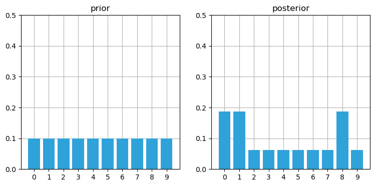

```python
hallway = np.array([1, 1, 0, 0, 0, 0, 0, 0, 1, 0])
prior = np.array([.1] * 10)
likelihood = lh_hallway(hallway, z=1, z_prob=.75)
posterior = update(likelihood, prior)
book_plots.plot_prior_vs_posterior(prior, posterior, ylim=(0,.5))
```

После первого обновления мы присвоили высокую вероятность каждому положению двери и низкую - каждой стене.

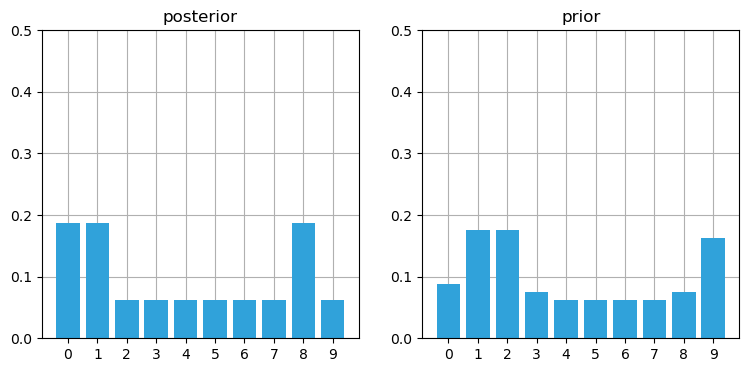

```python
kernel = (.1, .8, .1)
prior = predict(posterior, 1, kernel)
book_plots.plot_prior_vs_posterior(prior, posterior, True, ylim=(0,.5))
```

Шаг прогнозирования сместил эти вероятности вправо, немного размазав их. Теперь давайте посмотрим, что происходит на следующем этапе.

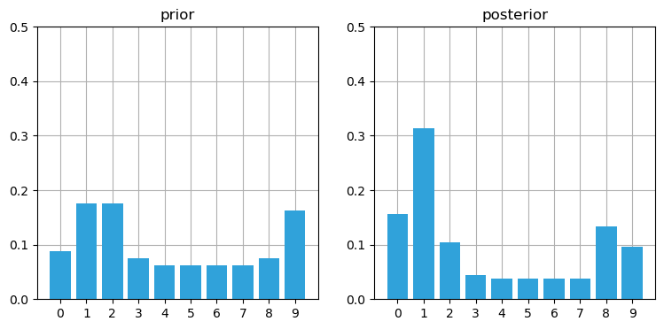

```python
likelihood = lh_hallway(hallway, z=1, z_prob=.75)
posterior = update(likelihood, prior)
book_plots.plot_prior_vs_posterior(prior, posterior, ylim=(0,.5))
```

Обратите внимание на высокую планку в положении 1. Это соответствует (правильному) варианту, когда мы начинаем с положения 0, обнаруживаем дверь, сдвигаем на 1 вправо и обнаруживаем другую дверь. Никакие другие положения не делают этот набор наблюдений столь вероятным. Теперь мы добавим обновление, а затем столкнемся со стеной.

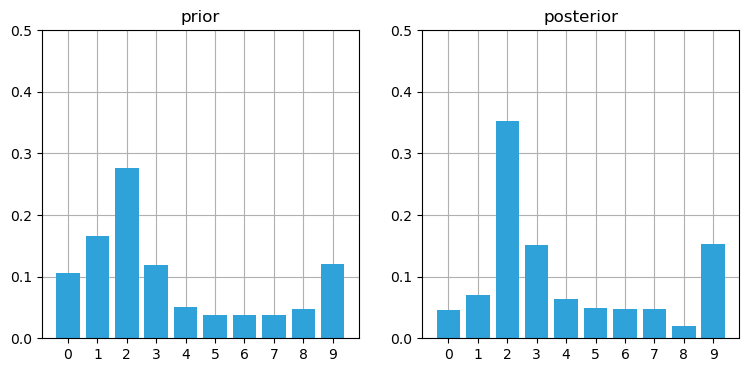

```python
prior = predict(posterior, 1, kernel)
likelihood = lh_hallway(hallway, z=0, z_prob=.75)
posterior = update(likelihood, prior)
book_plots.plot_prior_vs_posterior(prior, posterior, ylim=(0,.5))
```

У нас очень заметная полоса на позиции 2 со значением 35%. Это более чем в два раза превышает значение любой другой полосы на графике, чем на нашем предыдущем графике. Давайте посмотрим еще на один цикл.

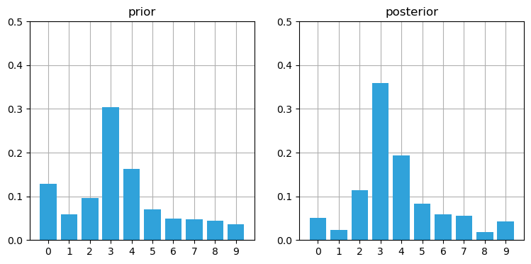

```python
prior = predict(posterior, 1, kernel)
likelihood = lh_hallway(hallway, z=0, z_prob=.75)
posterior = update(likelihood, prior)
book_plots.plot_prior_vs_posterior(prior, posterior, ylim=(0,.5))
```

Я проигнорировал важный вопрос. Ранее я предполагал, что у нас есть датчик движения для прогнозирования шага; затем, когда мы говорили о дроне и сообщении о доставке, я предположил, что вы не знали, что он внезапно полетел. Я упомянул, что ваша уверенность в том, что дрон летит, со временем будет возрастать, но я не предоставил для этого никакого кода. Так, как мы можем обнаружить и/или оценить изменения в модели процесса, если мы не измеряем их напрямую?

На данный момент я хочу проигнорировать эту проблему. В последующих главах мы рассмотрим математику, лежащую в основе этой оценки; на данный момент достаточно сложно просто изучить этот алгоритм. Решить эту проблему чрезвычайно важно, но мы еще не создали достаточного количества необходимого математического аппарата, и поэтому в оставшейся части главы мы будем игнорировать проблему, предполагая, что у нас есть датчик, который улавливает движение.

## Дискретный алгоритм Байеса

Эта диаграмма иллюстрирует алгоритм:

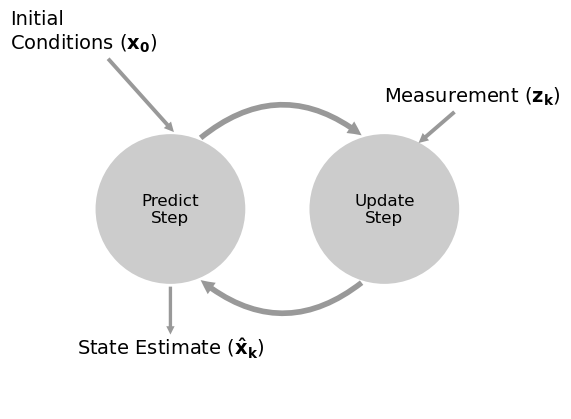

```python
book_plots.predict_update_chart()
```

Этот фильтр является разновидностью фильтра $g$-$h$. Здесь мы используем процентное соотношение ошибок для неявного вычисления параметров $g$ и $h$. Мы могли бы выразить дискретный алгоритм Байеса в виде $g$-$h$ фильтра, но это не внесло бы ясности в логику работы.

Уравнения фильтра имеют вид:

$$\begin{aligned} \bar {\mathbf x} &= \mathbf x \ast f_{\mathbf x}(\bullet)\, \, &\text{Predict Step} \\ \mathbf x &= \|\mathcal L \cdot \bar{\mathbf x}\|\, \, &\text{Update Step}\end{aligned}$$

$\mathcal L$ - это стандартный способ записи функции правдоподобия. Обозначение $\|\|$ означает использование нормы. Нам нужно нормализовать произведение вероятности на предшествующее, чтобы гарантировать, что $x$ - это распределение вероятностей, которое в сумме равно единице.

Мы можем выразить это в псевдокоде.

**Инициализация**

```
1. Инициализируем наше представление о состоянии
```

**Прогноз**

```
1. Основываясь на поведении системы, спрогнозируем состояние на следующем временном шаге
2. Скорректируем представление, чтобы учесть неопределенность в прогнозировании
```

**Обновление**

```
1. Получите измерения и их оценки точности
2. Вычислите, насколько вероятно, что измерение соответствует каждому состоянию
3. Обновите вектор представления с учетом этой вероятности
```

Когда мы будем рассматривать фильтр Калмана, мы будем использовать точно такой же алгоритм, отличаться будут только детали вычислений.

Алгоритмы в этой форме иногда называют "корректорами прогнозов". Мы делаем прогноз, а затем корректируем его.

Давайте напишем функции для выполнения фильтрации и отображения результатов на каждом шаге. Я выделил расположение дверных проемов черным цветом. Передние проемы выделены оранжевым, а задние - синим. Я провожу толстую вертикальную линию, чтобы указать, где на самом деле находится Делив-01. Это не результат работы фильтра - мы знаем, где находится Делив, только потому, что имитируем его движение.

```python
def discrete_bayes_sim(prior, kernel, measurements, z_prob, hallway):
    posterior = np.array([.1]*10)
    priors, posteriors = [], []
    for i, z in enumerate(measurements):
        prior = predict(posterior, 1, kernel)
        priors.append(prior)

        likelihood = lh_hallway(hallway, z, z_prob)
        posterior = update(likelihood, prior)
        posteriors.append(posterior)
    return priors, posteriors


def plot_posterior(hallway, posteriors, i):
    plt.title('Posterior')
    book_plots.bar_plot(hallway, c='k')
    book_plots.bar_plot(posteriors[i], ylim=(0, 1.0))
    plt.axvline(i % len(hallway), lw=5)
    plt.show()

def plot_prior(hallway, priors, i):
    plt.title('Prior')
    book_plots.bar_plot(hallway, c='k')
    book_plots.bar_plot(priors[i], ylim=(0, 1.0), c='#ff8015')
    plt.axvline(i % len(hallway), lw=5)
    plt.show()

def animate_discrete_bayes(hallway, priors, posteriors):
    def animate(step):
        step -= 1
        i = step // 2
        if step % 2 == 0:
            plot_prior(hallway, priors, i)
        else:
            plot_posterior(hallway, posteriors, i)

    return animate
```

Let's run the filter and animate it.

```python
from ipywidgets import interact, IntSlider
# change these numbers to alter the simulation
kernel = (.1, .8, .1)
z_prob = 1.0
hallway = np.array([1, 1, 0, 0, 0, 0, 0, 0, 1, 0])

# measurements with no noise
zs = [hallway[i % len(hallway)] for i in range(50)]

priors, posteriors = discrete_bayes_sim(prior, kernel, zs, z_prob, hallway)
interact(animate_discrete_bayes(hallway, priors, posteriors), step=IntSlider(value=1, max=len(zs)*2));
```

```
interactive(children=(IntSlider(value=1, description='step'), Output()), _dom_classes=('widget-interact',))
```

Теперь мы можем видеть результаты. Вы можете видеть, как индикатор prior меняет положение и снижает достоверность, а индикатор posterior остается в том же положении и повышает достоверность, поскольку он учитывает информацию, полученную в результате измерений. Я сделал измерения идеальными с помощью строки "z_prob = 1.0"; мы рассмотрим влияние неточных измерений в следующем разделе.

Еще одна вещь, на которую следует обратить внимание, это то, насколько точной становится наша оценка, когда мы находимся перед дверью, и насколько она ухудшается, когда мы находимся в середине коридора. Здесь всего несколько дверных проемов, поэтому, когда датчик сообщает нам, что мы находимся перед дверью, это повышает нашу уверенность в том, что мы находимся в нужном месте. Длинный отрезок без дверей снижает нашу уверенность.

## Недостатки и ограничения

Пусть вас не вводит в заблуждение простота примера, который я выбрал. Это надежный и самодостаточный фильтр, и вы можете использовать код в реальных решениях. Если вам нужен мультимодальный дискретный фильтр, этот фильтр подойдет.

Но такой фильтр используется нечасто, поскольку у него есть ряд ограничений. Как обойти эти ограничения, и будет рассказано в последующих главах этого курса.

Первая проблема - это масштабирование. В нашей задаче по отслеживанию дрона использовалась только одна переменная, $pos$, для обозначения местоположения. В наиболее интересных задачах требуется отслеживать несколько объектов в большом пространстве. Реально, как минимум, мы хотели бы отслеживать координаты нашего дрона $(x, y, z)$ и, возможно, его скорость $ (\dot {x},\dot {y}, \dot {z})$. Мы не рассматривали многомерный случай, но вместо массива мы используем многомерную сетку для хранения вероятностей о каждом отдельном местоположении. Каждый шаг `update()` и `predict()` требует обновления всех значений в таблице, поэтому простая задача с четырьмя переменными потребует $O(n^4)$ времени выполнения *на каждый временной шаг*. Настоящие фильтры могут оценивать 10 или более переменных, что приводит к непомерным требованиям к вычислениям.

Вторая проблема заключается в том, что фильтр дискретен, но мы живем в непрерывном мире. Гистограмма требует, чтобы вы моделировали выходные данные вашего фильтра в виде набора дискретных точек. Для моделирования коридора длиной 100 метров требуется 10 000 позиций с точностью до 1 см. Таким образом, каждая операция обновления и прогнозирования потребует выполнения расчетов для 10 000 различных вероятностей. По мере добавления размеров ситуация становится экспоненциально хуже. Для внутреннего двора размером 100х100 м $^2$ требуется 100 000 000 контейнеров гистограммы, чтобы получить точность в 1 см.

Третья проблема заключается в том, что фильтр является мультимодальным. Фильтры твердых частиц, которые мы рассмотрим позже, являются мультимодальными и часто используются из-за этого свойства. Но представьте, что ГНСС в вашем автомобиле сообщает вам, что он на 40% уверен, что вы находитесь на проспекте Карла Маркса, и на 30% уверен, что вы находитесь на Площади Калинина.

Четвертая проблема заключается в том, что для этого требуется измерение состояния. Нам нужен датчик движения, чтобы определять, насколько сильно двигается объект. Есть способы обойти эту проблему, но это усложнило бы изложение данной главы, поэтому, учитывая вышеупомянутые проблемы, я не буду обсуждать их дальше.

С учетом сказанного, если бы у меня была небольшая проблема, с которой мог бы справиться этот метод, я бы предпочел использовать его; реализовать, отладить и понять все достоинства тривиально.

## Отслеживание и контроль

Мы пассивно отслеживали автономно движущийся объект. Но рассмотрим очень похожую проблему. Я автоматизирую склад и хочу использовать роботов для сбора всех товаров для заказа клиента. Возможно, самый простой способ сделать это - заставить роботов передвигаться по железнодорожным путям. Я хочу, чтобы у робота была возможность указать пункт назначения и отправить его туда. Но железнодорожные пути и двигатели роботов несовершенны. Проскальзывание колес и неисправность двигателей означают, что робот вряд ли сможет переместиться точно в указанное вами положение. Роботов несколько, и нам нужно знать, где они все находятся, чтобы не допустить их поломки.

Поэтому мы добавляем датчики. Возможно, мы установим магниты на дорожке через каждые несколько метров и будем использовать датчик Холла для подсчета количества пройденных магнитов. Если мы насчитаем 10 магнитов, то робот должен быть у 10-го магнита. Конечно, можно либо пропустить магнит, либо пересчитать его дважды, поэтому мы должны учитывать некоторую погрешность. Мы можем использовать код из предыдущего раздела для отслеживания нашего робота, поскольку подсчет магнитов очень похож на обнаружение дверного проема.

Но мы еще не закончили. Мы научились никогда не выбрасывать информацию. Если у вас есть информация, вы должны использовать ее для улучшения своей оценки. Какую информацию мы упускаем? Мы знаем, какие управляющие сигналы мы подаем на колеса робота в каждый момент времени. Например, предположим, что раз в секунду мы посылаем роботу команду на перемещение - переместиться влево на 1 единицу, переместиться вправо на 1 единицу или остаться на месте. Если я пошлю команду "переместиться влево на 1 единицу", я ожидаю, что через секунду робот окажется на 1 единицу левее того места, где он находится сейчас. Это упрощение, потому что я не учитываю ускорение, но и не пытаюсь преподавать теорию управления. Колеса и двигатели несовершенны. В конечном итоге робот может оказаться на расстоянии 0,9 единицы, а может быть, и 1,2 единицы.

## Теорема Байеса и теорема о полной вероятности

В этой главе мы разработали математику, просто проанализировав информацию, которой мы располагаем в каждый момент времени. В процессе мы открыли для себя [*Теория Байеса - Bayes' Theorem*](https://en.wikipedia.org/wiki/Bayes%27_theorem) и [*Теорему о полной вероятности - Total Probability Theorem*](https://en.wikipedia.org/wiki/Law_of_total_probability).

Теорема Байеса объясняет нам, как вычислить вероятность события, учитывая предыдущую информацию.

Мы реализовали функцию `update()` для вычисления этой вероятности:

$$ \mathtt{posterior} = \frac{\mathtt{likelihood}\times \mathtt{prior}}{\mathtt{normalization\, factor}}$$

Каждый фильтр в этом курсе является выражением теоремы Байеса.

$$ updated\,knowledge = \big\|likelihood\,of\,new\,knowledge\times prior\, knowledge \big\|$$

где $\| \cdot\|$ означает нормализацию.

Мы пришли к этому с помощью простых рассуждений о Деливе-01, летящему по коридору. Однако, как мы увидим в дальнейшем, то же самое уравнение применимо ко множеству задач фильтрации. Мы будем использовать это уравнение в каждой последующей главе.

Аналогичным образом, на этапе `predict()` вычисляется общая вероятность нескольких возможных событий. В статистике это называется *Теоремой о полной вероятности*, и мы также будем использовать этот алгоритм в следующей главе после введения некоторых вспомогательных математических методов.

Важно закрепить для себя тот факт, что *теорема Байеса - это формула для включения новой информации в существующую.*

## Резюме

Мы реализовали своего рода байесовский фильтр, написав не так уж и много кода, это впечатляет! Мы научились начинать с отсутствия информации и извлекать информацию из зашумленных датчиков. Несмотря на то, что датчики, описанные в этой главе, очень шумные (например, точность большинства датчиков превышает 80%), мы быстро определяем наиболее вероятное местоположение нашего дрона Делива-01. Мы узнали, что этап прогнозирования всегда ухудшает наши знания, но добавление другого измерения, даже если в нем могут быть помехи, улучшает наши знания, позволяя нам прийти к наиболее вероятному результату.

Этот курс в основном посвящен фильтру Калмана. Математические методы, которые в нем используются, отличаются, но логика в точности такая же, как и в этой главе. В нем используются байесовские рассуждения для формирования оценок на основе комбинации измерений и моделей процессов.

**Если вы разберетесь в этой главе, вы сможете понять и реализовать фильтры Калмана.** Я не могу не подчеркнуть этого. Если что-то покажется вам непонятным, вернитесь назад, перечитайте эту главу и поиграйте с кодом. Остальная часть этой книги будет основана на алгоритмах, которые мы здесь используем. Если вы не понимаете, почему работает этот фильтр, то вряд ли добьетесь успеха в изучении остального материала. Однако, если вы усвоите фундаментальную идею - умножение вероятностей при измерении и изменение вероятностей при обновлении приводит к сходящемуся решению, - то, немного изучив математику, вы будете готовы к внедрению фильтра Калмана.